# LightGBM Challenger

Does a flexible model find signal the scorecard misses? · Flagship PD Model · Stage 3

Author: Chuch · Written with AI assistance

## The short version

+0.029Gini uplift over the scorecard

A gradient-boosted tree model on the **same 12 fields and the same applicants** finds only a modest gain over the scorecard:

- **Test Gini** 0.522 against the scorecard’s 0.493
- **Uplift** of +0.029, inside the “review” band, just below the “rebuild” line
- **Train/test gap** 0.054 after one regularised refit, passing the 0.06 limit

**The scorecard stays champion.** The challenger finds a little more signal, but not enough to justify losing field-by-field explainability.

## The question

The scorecard is easy to explain, but it only looks at each field’s bins and how they add up. A tree model can find **interactions**: patterns where two fields matter more together than apart.

The test is fair. Both models score the same test applicants with the same 12 fields, so any difference is the model, not the data.

## Success criteria, set before fitting

| Criterion | Rule |
| --- | --- |
| 1.1a Gini uplift | Under 0.008: retain (noise). 0.008 to 0.03: retain and review interactions. Over 0.03: rebuild the scorecard. |
| 1.1b Train/test gap | At most 0.06 |
| 1.1c Rank ordering | Strictly rising across test deciles, zero reversals |
| 1.1d Calibration | Mean predicted risk within 0.44 pp of the actual rate |

## Did the first model overfit?

The first LightGBM fit memorised its training rows. Its train/test gap was **0.065**, above the 0.06 limit, so its uplift could not be used.

One refit with shallower trees and bigger leaves brought the gap to **0.054** with no loss of test Gini. Only the refit is carried forward.

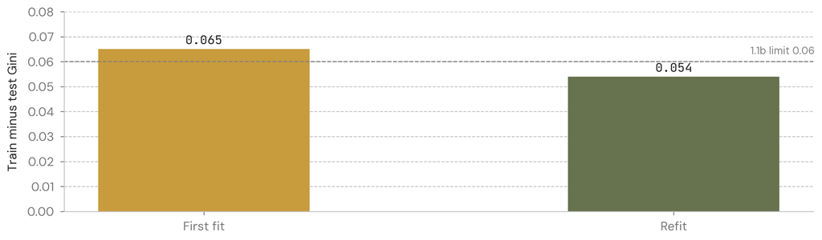

## Test results: challenger against scorecard

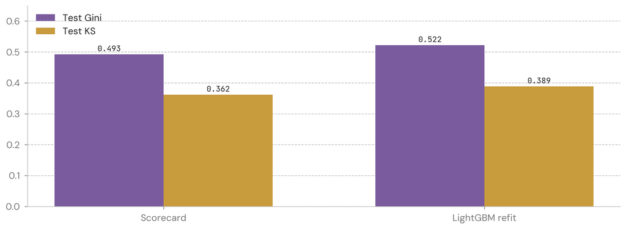

The refit’s test Gini is 0.522, an uplift of +0.029. That sits **0.0006 below the rebuild line**. The test Gini’s standard error is about 0.008, so the honest reading is “retain, and treat as borderline.”

## Rank ordering and calibration

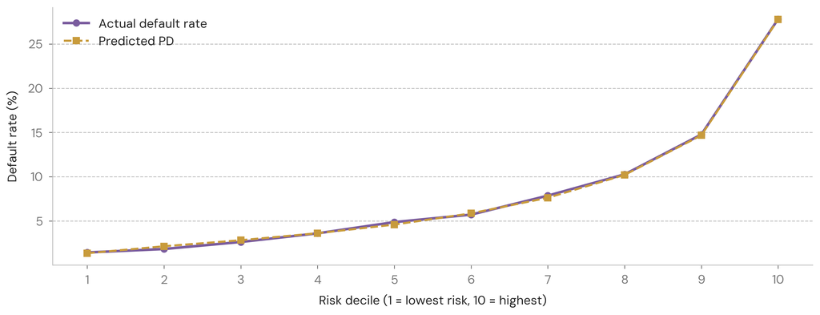

Risk rises with every decile, so the ranking passes (1.1c). The overall mean predicted risk is within a fraction of a percentage point of the actual rate, which passes 1.1d. Individual deciles differ by up to about 0.3 pp, with no consistent direction. That is a calibration detail to watch, not a failure.

## What the model relies on

Gain importance shows how much each field improves the trees. It is the tree equivalent of the scorecard’s coefficients, but it doesn’t show direction.

Share of total gain, LightGBM refit

|  | share of gain |
| --- | --- |
| EXT_SOURCE_3 | 29.0% |
| EXT_SOURCE_2 | 26.1% |
| ANNUITY_CREDIT | 12.0% |
| EXT_SOURCE_1 | 8.8% |
| CREDIT_GOODS | 5.8% |
| DAYS_EMPLOYED | 5.7% |
| AMT_GOODS_PRICE | 4.2% |
| OCCUPATION_TYPE | 3.6% |
| ORG_BAND | 2.2% |
| NAME_EDUCATION_TYPE | 1.7% |
| REGION_RATING_CLIENT_W_CITY | 0.8% |
| NAME_INCOME_TYPE | 0.3% |

The external credit scores dominate, which matches the scorecard. The model is not telling a different story about which fields matter.

## Caveats

- **Explainability.** A tree ensemble can’t be read field by field the way the scorecard can. Explaining an individual decision needs an extra tool, such as SHAP, which hasn’t been run yet.
- **Single model and seed.** One refit, one random seed. Seed sensitivity is not tested.
- **Target proxy.** Same payment-difficulty outcome as the scorecard, not a regulatory default.
- **Tuning.** No hyperparameter search. The refit was chosen by the train/test gap rule. The test Gini was shown before the refit, so the result is not a fully blind test.

## The call

**Keep the scorecard as champion.** The LightGBM refit passes every check, but its uplift is small and borderline. The next step is to examine the tree’s strongest interactions as candidate terms for a v2 scorecard, which keeps the explainability.